# Probability Distribution

Ridlo W. Wibowo | last update: 2022-03-14

## Random variables

- Discrete: can take only limited number of values (i.e. integer value)

  Example:
  - flipping a coin {H, T}
  - rolling a dice {1, 2, 3, 4, 5, 6}
- Continuous: can take any value (i.e. real number)

  Example:
  - height of human
  - mass of rocks
- Data distribution $\rightarrow$ Probability distribution
- Frequency plot / histogram
- Example:

  | Height | Number of student (freq) | Probability | | --- | --- | --- | | 150-155 | 28 | 0.112 | | 155-160 | 43 | 0.172 | | 160-165 | 57 | 0.228 | | 165-170 | 62 | 0.248 | | 170-175 | 48 | 0.192 | | 175-180 | 12 | 0.048 | | **Total** | 250 | 1.0 |

## Probability Distribution

---of random variables

depend on the data/variable types:

- discrete (probability mass function; pmf)
- continuous (probability density function; pdf)

### Probability Mass Function (pmf)

is a function that gives the probability that a discrete random variable ($X$) is exactly equal to some value.

- $x$-axis is random variable, $y$-axis is the probability Pr($x$)
- Example: in a box there are 10 balls of 1, 3, and 7: {1, 1, 3, 3, 3, 3, 3, 7, 7, 7}, what is the **pmf** when we randomly select one ball?

[figure not shown]

### Probability Density Function (pdf)

A random variable $X$ has probability density function $f_X$ $$\text{Pr}(a \geq X \geq b) = \int_a^b f_X (x) dx$$

For normalized pdf: $$\int_{-\infty}^{+\infty} f(x) dx = 1$$

### Cumulative Distribution Function (**cdf**)

- for discrete random variable:

  $$F_X(x) = \text{P}(X \leq x)$$
- for continuous random variable:

  $$F_X(x) = \int_{-\infty}^{x} f_X(x) dx$$

  $$f_X(x) = \frac{d}{dx} F_X(x)$$
- we can use histogram to plot the distribution or use the dot/lines (ogive or ogive graph; *oh-jive*). It's very similar to a histogram, only instead of rectangles, an ogive has a single point marking where the top right of the rectangle would be

[figure not shown]

### Inverse-CDF (ppf)

- alias: quantile function / percent point function (**ppf**)
- the $x$-axis is cumulative distribution function $F_X(x) = P(X \leq x)$ from 0 to 1 while the $y$-axis is the random variable ($X$)

  $$F^{-1}(p), p \in (0, 1)$$

*Remember*

### Descriptive statistics: how we describe the data distribution $\rightarrow$ probability distribution

- Mode, Median, and Mean

[figure not shown]

- **Moment** in probability distribution
  - 0th = Total probability, i.e. 1
  - 1th = Expected value (Mean)
  - 2nd central = Variance
  - 3th standardized = Skewness
  - 4th standardized = Kurtosis
- We often use median (quantile 0.5, percentile 50)--not the mean, to describe the random variables, esp. for data/variable with many outliers.
- Statistics symbols: https://mathvault.ca/hub/higher-math/math-symbols/probability-statistics-symbols/

### Common Probability Distributions

- Every random variable (quantity) in *nature*, has **a certain shape of probability distribution**, it is usually depend on the physical process and interaction that occur when producing that random variable.

  Example:
  - Flipping a coin
  - Height of students
  - Mass/size distribution of the broken glass
  - Speed distribution of atoms/molecules inside a container
  - ...
- Many probability distributions that are *important* in theory or applications (frequently seen in nature) have been given **specific names**.
  - Discrete
    - Binomial
    - Poisson
    - Boltzmann
    - ...
  - Continuous
    - Uniform/Rectangle
    - Beta
    - Normal/Gaussian
    - Cauchy
    - Exponential
    - ...

    https://en.wikipedia.org/wiki/List_of_probability_distributions

## Binomial Distribution

It is the answer to these kind of questions:

- What is the probability to get 6 H when you flip a coin 6 times?
- What is the probability to get 4 H and 2 T, when you flip a coin 6 times?
- From the survey of Otakus, 55% of them likes Boruto. If you ask 5 of your Otakus friends, what is the probability that exactly 4 of them likes Boruto?
- From the survey of Otakus, 55% of them likes Boruto. If you ask 5 of your Otakus friends, what is the probability that none of them likes Boruto?

An experiment is a binomial experiment if:

- It is repeated a fixed number of times ($n$ times).
- The trials are independent.
- Trials have two mutually exclusive outcomes, either success or failure.
- The probability of success ($p$) is the same for all trials.

If $n=1$ its is called Bernoulli trial/distribution.

The probability of getting exactly $k$ successes in $n$ independent *Bernoulli trials* is given by the probability mass function:

$$P(x=k) = \binom{n}{k}p^k q^{n-k}$$

where,

- probability of success, $p$
- probability of failure, $q = 1-p$
- number of success, $k$
- number of trial, $n$

Expected value and variance of binomial distribution: $$\text{E}(x) = np$$ $$\text{Var}(x) = np(1-p) = npq$$

**Example**

- Survei penyuka bubur ayam mengatakan bahwa 60% orang suka mengaduknya sebelum makan. Berapa probabilitas ketika saya bertanya kepada 10 orang mendapati 1 orang suka mengaduk dan 9 yang lain tidak suka mengaduk?

[figure not shown]

```
n : 10
p:  0.6
k:  [ 0  1  2  3  4  5  6  7  8  9 10]
Mean: 6.0
Var: 2.4000000000000004
Skew: -0.12909944487358052
Kurt: -0.1833333333333333
Peluang mendapati 0 orang suka ngaduk bubur ayam dari 10 orang yang ditanya: 0.00010485760000000014
Peluang mendapati 1 orang suka ngaduk bubur ayam dari 10 orang yang ditanya: 0.0015728640000000028
Peluang mendapati 2 orang suka ngaduk bubur ayam dari 10 orang yang ditanya: 0.010616832
Peluang mendapati 3 orang suka ngaduk bubur ayam dari 10 orang yang ditanya: 0.04246732800000004
Peluang mendapati 4 orang suka ngaduk bubur ayam dari 10 orang yang ditanya: 0.11147673600000013
Peluang mendapati 5 orang suka ngaduk bubur ayam dari 10 orang yang ditanya: 0.20065812480000034
Peluang mendapati 6 orang suka ngaduk bubur ayam dari 10 orang yang ditanya: 0.2508226560000002
Peluang mendapati 7 orang suka ngaduk bubur ayam dari 10 orang yang ditanya: 0.21499084800000012
Peluang mendapati 8 orang suka ngaduk bubur ayam dari 10 orang yang ditanya: 0.12093235199999994
Peluang mendapati 9 orang suka ngaduk bubur ayam dari 10 orang yang ditanya: 0.04031078400000004
Peluang mendapati 10 orang suka ngaduk bubur ayam dari 10 orang yang ditanya: 0.0060466176
```

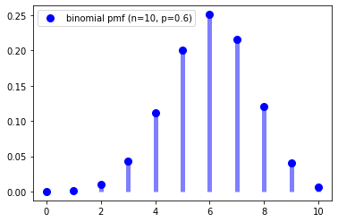

```python
import numpy as np
from scipy.stats import binom
import matplotlib.pyplot as plt

n, p = 10, 0.6
x = np.arange(0,11)
print("n :", n)
print("p: ", p)
print("k: ", x)
mean, var, skew, kurt = binom.stats(n, p, moments='mvsk')
print(f"Mean: {mean}\nVar: {var}\nSkew: {skew}\nKurt: {kurt}")

for xi in x:
    print(f"Peluang mendapati {xi} orang suka ngaduk bubur ayam dari 10 orang yang ditanya: {binom.pmf(xi, n, p)}")

fig, ax = plt.subplots(1, 1)
ax.plot(x, binom.pmf(x, n, p), 'bo', ms=8, label='binomial pmf (n='+str(n)+', p='+str(p)+')')
ax.vlines(x, 0, binom.pmf(x, n, p), colors='b', lw=5, alpha=0.5)
plt.legend()
```

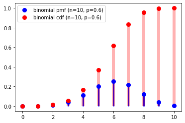

```python
fig, ax = plt.subplots(1, 1)
ax.plot(x, binom.pmf(x, n, p), 'bo', ms=8, label=f'binomial pmf (n={n}, p={p})')
ax.vlines(x, 0, binom.pmf(x, n, p), colors='b', lw=3, alpha=1.0)

ax.plot(x, binom.cdf(x, n, p), 'ro', ms=8, label=f'binomial cdf (n={n}, p={p})')
ax.vlines(x, 0, binom.cdf(x, n, p), colors='r', lw=6, alpha=0.3)
plt.legend()
```

### Binomial Test

is an exact **test** of the statistical significance of deviations from a theoretically expected distribution of observations into *two categories*.

Example:

- In a particular game, the dice is rolled 300 times, and 6 comes up 100 times, is the dice fair?
- We did a survey on how people usually eat a chicken porridge. From 10 people we ask, 6 say that they like to mix the topping, and 4 of them don't like it, can we say that the majority of people like to mix the topping? or could it be that people, in general, don't have preference, and this result are just due to random chance and a small sample size?
- ...

We can compute the $p$-value (what is that?) ... learn more about **these statistical tests** in *inferential statistics*.

## Poisson Distribution

- The Poisson probability distribution is used when computing the probability of **a certain number of successes within a specified interval** of time or space (length or area or volume).
- An experiment follows the Poisson process if:
  - The probability of two successes in a small enough interval is 0%.
  - The probability of a success is the same for any two intervals which share the same length.
  - Successes are independent of successes in other intervals.
- Example:
  - The number of car accidents in a day.
  - The number of grass in a square metre plot of land.
  - The number of photon arrived from a star in a second.
- It can be derived from binomial distribution when $\lim_{n \rightarrow \infty}$; with $\lambda = np$ or $ p =\frac{\lambda}{n}$
- Probability of an event occurs $k$ times in an interval of time or space ($t$) given a time rate for the number of events $r$ to happen.

  $$f(k; \lambda) = P(x=k; \lambda) = \frac{(r t)^{k}}{k!} e^{-r t} = \frac{\lambda^k}{k!} e^{-\lambda}$$

  $$k = 0, 1, 2, \ldots$$
- $\lambda= rt$ or $\mu$ is the average number of event occurs in a specified time interval/region $t$
- Expected value and the variance of Poisson distribution is $\lambda$

  $$\text{E}(x) = \text{Var}(x) = \lambda$$

### Derivation the Poisson Distribution from the Binomial Distribution

The binomial distribution works when we have a fixed number of events $n$, each with a constant probability of success $p$. Imagine we don't know the number of trials that will happen. Instead, we only know the average number of successes per time period. So we know the rate of successes per day, but not the number of trials $n$ or the probability of success $p$ that led to that rate.

Define a number

$$\lambda = np$$

Let this be the rate of successes per day. It's equal to $np$. That's the number of trials $n$ — however many there are — times the chance of success $p$ for each of those trials. Think of it like this: if the chance of success is $p$ and we run $n$ trials per day, we'll observe $np$ successes per day on average. That's our observed success rate lambda.

Recall that the binomial distribution,

$$\lim_{n \rightarrow \infty} P(x=k)= \lim_{n \rightarrow \infty} \frac{n!}{(n-k)! k!} p^k (1-p)^{n-k}$$$$= \lim_{n \rightarrow \infty} \frac{n!}{(n-k)! k!} \left( \frac{\lambda}{n} \right)^k \left(1- \frac{\lambda}{n}\right)^{n-k}$$$$= \left( \frac{\lambda^k}{k!} \right) \lim_{n \rightarrow \infty} \frac{n!}{(n-k)!} \left( \frac{1}{n} \right)^k \left(1- \frac{\lambda}{n}\right)^{n-k}$$

The first part,

$$\lim_{n \rightarrow \infty} \frac{n!}{(n-k)!} \left( \frac{1}{n} \right)^k = \lim_{n \rightarrow \infty} \frac{(n)(n-1)(n-2) \ldots (n-k)(n-k-1) \ldots (1)}{(n-k)(n-k-1) \ldots (1)}\left( \frac{1}{n} \right)^k$$$$=\lim_{n \rightarrow \infty} \frac{(n)(n-1)(n-2) \ldots (n-k+1)}{n^k} = \frac{n^k}{n^k} = 1$$

The second part,

$$\lim_{n \rightarrow \infty} \left(1 - \frac{\lambda}{n}\right)^{n-k} = \lim_{n \rightarrow \infty} \left(1 - \frac{\lambda}{n}\right)^{n} \left(1 - \frac{\lambda}{n}\right)^{-k}$$

if we define, $x = -\frac{n}{\lambda}$

$$\lim_{n \rightarrow \infty} \left(1 + \frac{1}{x}\right)^{-\lambda} \cdot \lim_{n \rightarrow \infty} \left(1 - \frac{\lambda}{n}\right)^{-k} = e^{-\lambda} \cdot 1$$

We can conclude,

$$P(x=k; \lambda)= \frac{\lambda^k}{k!} e^{-\lambda}$$

References:

- https://medium.com/@andrew.chamberlain/deriving-the-poisson-distribution-from-the-binomial-distribution-840cc1668239
- https://towardsdatascience.com/poisson-distribution-intuition-and-derivation-1059aeab90d

**Example**

1. Seorang astronom mengamati sebuah bintang neutron dengan detektor X-ray. Detektor menerima rata-rata 10 foton per detik dari bintang neutron tersebut. Berapa probabilitas detektor menerima 25 foton dalam waktu 2 detik dari bintang neutron tersebut? (Ans: 4.45%)
2. If electricity power failures occur according to a Poisson distribution with an average of 5 failures every twenty weeks, calculate the probability that there will not be more than one failure during a particular week.

```
mean :  20.0
var  :  20.0
skew :  0.22360679774997896
kurt :  0.05
Peluang mendapatkan 5 foton dalam 2 detik adalah 5.496409659836144e-05
Peluang mendapatkan 6 foton dalam 2 detik adalah 0.00018321365532787177
Peluang mendapatkan 7 foton dalam 2 detik adalah 0.0005234675866510618
Peluang mendapatkan 8 foton dalam 2 detik adalah 0.0013086689666276534
Peluang mendapatkan 9 foton dalam 2 detik adalah 0.002908153259172565
Peluang mendapatkan 10 foton dalam 2 detik adalah 0.00581630651834512
Peluang mendapatkan 11 foton dalam 2 detik adalah 0.01057510276062752
Peluang mendapatkan 12 foton dalam 2 detik adalah 0.017625171267712562
Peluang mendapatkan 13 foton dalam 2 detik adalah 0.02711564810417317
Peluang mendapatkan 14 foton dalam 2 detik adalah 0.03873664014881865
Peluang mendapatkan 15 foton dalam 2 detik adalah 0.05164885353175814
Peluang mendapatkan 16 foton dalam 2 detik adalah 0.06456106691469761
Peluang mendapatkan 17 foton dalam 2 detik adalah 0.07595419637023251
Peluang mendapatkan 18 foton dalam 2 detik adalah 0.08439355152248075
Peluang mendapatkan 19 foton dalam 2 detik adalah 0.0888353173920848
Peluang mendapatkan 20 foton dalam 2 detik adalah 0.0888353173920848
Peluang mendapatkan 21 foton dalam 2 detik adalah 0.08460506418293791
Peluang mendapatkan 22 foton dalam 2 detik adalah 0.07691369471176195
Peluang mendapatkan 23 foton dalam 2 detik adalah 0.06688147366240117
Peluang mendapatkan 24 foton dalam 2 detik adalah 0.05573456138533489
Peluang mendapatkan 25 foton dalam 2 detik adalah 0.04458764910826764
Peluang mendapatkan 26 foton dalam 2 detik adalah 0.03429819162174451
Peluang mendapatkan 27 foton dalam 2 detik adalah 0.025406067867958883
Peluang mendapatkan 28 foton dalam 2 detik adalah 0.01814719133425623
Peluang mendapatkan 29 foton dalam 2 detik adalah 0.012515304368452648
Peluang mendapatkan 30 foton dalam 2 detik adalah 0.008343536245635134
Peluang mendapatkan 31 foton dalam 2 detik adalah 0.005382926610087127
Peluang mendapatkan 32 foton dalam 2 detik adalah 0.003364329131304493
Peluang mendapatkan 33 foton dalam 2 detik adalah 0.002038987352305724
Peluang mendapatkan 34 foton dalam 2 detik adalah 0.0011994043248857392
Peluang mendapatkan 35 foton dalam 2 detik adalah 0.0006853738999347143
```

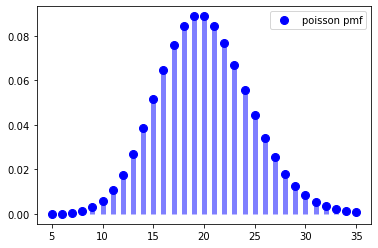

```python
from scipy.stats import poisson
import matplotlib.pyplot as plt

mu = 20
mean, var, skew, kurt = poisson.stats(mu, moments='mvsk')
print("mean : ", mean)
print("var  : ", var)
print("skew : ", skew)
print("kurt : ", kurt)

x = np.arange(5, 36)

for xi in x:
    print(f"Peluang mendapatkan {xi} foton dalam 2 detik adalah {poisson.pmf(xi, mu)}")

fig, ax = plt.subplots(1, 1)
ax.plot(x, poisson.pmf(x, mu), 'bo', ms=8, label='poisson pmf')
ax.vlines(x, 0, poisson.pmf(x, mu), colors='b', lw=5, alpha=0.5)
plt.legend()
```

```
mean :  0.25
var  :  0.25
skew :  2.0
kurt :  4.0
k    :  [0 1 2 3 4 5 6 7 8 9]
Peluang 0 kali mati listrk dalam seminggu = 0.7788007830714049.
Peluang 1 kali mati listrk dalam seminggu = 0.19470019576785122.
Peluang 2 kali mati listrk dalam seminggu = 0.024337524470981402.
Peluang 3 kali mati listrk dalam seminggu = 0.00202812703924845.
Peluang 4 kali mati listrk dalam seminggu = 0.00012675793995302808.
Peluang 5 kali mati listrk dalam seminggu = 6.337896997651408e-06.
Peluang 6 kali mati listrk dalam seminggu = 2.6407904156880876e-07.
Peluang 7 kali mati listrk dalam seminggu = 9.431394341743183e-09.
Peluang 8 kali mati listrk dalam seminggu = 2.947310731794738e-10.
Peluang 9 kali mati listrk dalam seminggu = 8.186974254985393e-12.
```

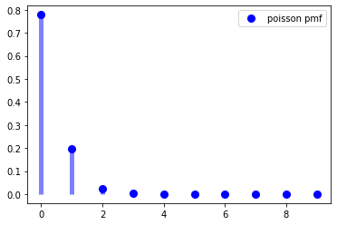

```python
mu = 5./20.
mean, var, skew, kurt = poisson.stats(mu, moments='mvsk')
print("mean : ", mean)
print("var  : ", var)
print("skew : ", skew)
print("kurt : ", kurt)

x = np.arange(0, 10)
print("k    : ", x)

for xi in x:
    print(f"Peluang {xi} kali mati listrk dalam seminggu = {poisson.pmf(xi, mu)}.")

fig, ax = plt.subplots(1, 1)
ax.plot(x, poisson.pmf(x, mu), 'bo', ms=8, label='poisson pmf')
ax.vlines(x, 0, poisson.pmf(x, mu), colors='b', lw=5, alpha=0.5)
plt.legend()
```

**Exercise**

- Vehicles pass through a junction on a busy road at an average rate of 600 per hour.
  - Find the probability that none passes in a given minute.
  - What is the expected number passing in two minutes?
  - Find the probability that this expected number actually pass through in a given two-minute period.

## Uniform Distribution

- A uniform/rectangle distribution means there is a flat constant probability of a value occurring within a given range, and is concerned with events that are equally likely to occur.
- PDF for uniform distribution:

$$ f(x)=\begin{cases} \frac{1}{b - a} & \mathrm{for}\ a \le x \le b, \\[8pt] 0 & \mathrm{for}\ x<a\ \mathrm{or}\ x>b \end{cases} $$

[figure not shown]

- The mean and median value is the same,

$$\mu = \frac{1}{2} (a + b)$$

- Variance of the uniform distribution is

$$\sigma^2 = \frac{(b - a)^2}{12}$$

- CDF:

$$ F(x)= \begin{cases} 0 & \text{for }x < a \\[8pt] \frac{x-a}{b-a} & \text{for }a \le x \le b \\[8pt] 1 & \text{for }x > b \end{cases} $$

[figure not shown]

- Inverse CDF:

$$F^{-1}(p) = a + p (b - a) \,\,\text{ for } 0<p<1$$

## Normal/Gaussian Distribution

- Normal distributions are important in statistics and are often used in the natural and social sciences to represent real-valued random variables *whose distributions are not known*.
- Their importance is partly due to the **central limit theorem**.
- PDF for normal distribution: $$f(x) = \varphi(x) = \frac{1}{\sigma \sqrt{2\pi}} e^{-\frac{1}{2} \left( \frac{x - \mu}{\sigma} \right)^2 } $$
  - The parameter $\mu$ is the mean or expectation of the distribution (and also its median and mode)
  - The parameter $\sigma$ is its standard deviation. The variance of the distribution is $\sigma^{2}$.
- CDF: $$F(x) = \Phi(x) = \frac{1}{2}\left[ 1 + \text{erf}\left( \frac{x-\mu}{\sigma \sqrt{2}} \right) \right]$$

[figure not shown]

- Symbol: $X \sim \mathcal{N}(\mu, \sigma^2)$
- Standard normal distribution: $Z = \mathcal{N}(0, 1)$
- A normal distribution can be transform to standard normal distribution:

  $Z = \frac{X - \mu}{\sigma}$

  or vice versa

  $X = \sigma Z + \mu$
- Gaussian distributions have some unique properties that are valuable in analytic studies:
  - any linear combination of a fixed collection of normal deviates is a normal deviate.
  - Many results and methods, such as propagation of uncertainty and least squares parameter fitting, can be derived analytically in explicit form when the relevant variables are normally distributed.

```
[-0.35963757 -0.84208948  2.43141597 ... -0.41710571 -1.37932239
 -0.30857413]
Count [51]:  [  1.   3.   4.   7.   5.  13.  17.  27.  34.  47.  74.  85. 145. 150.
 215. 240. 279. 379. 407. 466. 467. 522. 564. 603. 563. 620. 565. 514.
 541. 442. 395. 365. 289. 229. 167. 133. 113.  90.  61.  48.  36.  26.
  20.  16.   7.   4.   0.   0.   1.   0.   1.]
bins:  [-3.61009716 -3.46163926 -3.31318136 -3.16472346 -3.01626556 -2.86780766
 -2.71934976 -2.57089186 -2.42243396 -2.27397606 -2.12551816 -1.97706026
 -1.82860235 -1.68014445 -1.53168655 -1.38322865 -1.23477075 -1.08631285
 -0.93785495 -0.78939705 -0.64093915 -0.49248125 -0.34402335 -0.19556545
 -0.04710755  0.10135035  0.24980825  0.39826615  0.54672405  0.69518195
  0.84363985  0.99209775  1.14055565  1.28901355  1.43747145  1.58592935
  1.73438725  1.88284515  2.03130305  2.17976095  2.32821885  2.47667675
  2.62513465  2.77359255  2.92205045  3.07050835  3.21896625  3.36742415
  3.51588205  3.66433995  3.81279785  3.96125575]
width:  0.14845790018758098
 -------------
Not normalized, total: number of data/population/sample
```

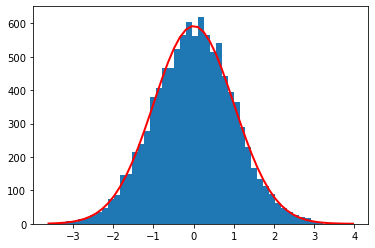

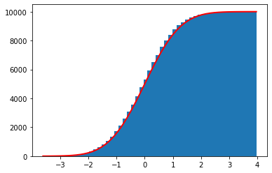

```
 -------------
Normalized, total: 1
```

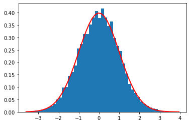

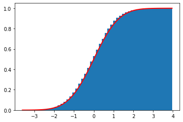

```python
## Example of data with Normal distribution
mu = 0.0
sigma = 1.0
Nsample = 10000

s = np.random.normal(mu, sigma, Nsample) # normal/gaussian dist. random number generator
print(s)

nbins=51

from scipy.special import erf # for cdf plot

count, bins, ignored = plt.hist(s, nbins);
width = bins[1]-bins[0]
print(f"Count [{len(count)}]: ", count)
print("bins: ", bins)
print("width: ", width)

print(" ------------- ")
print("Not normalized, total: number of data/population/sample")

plt.plot(bins, Nsample*width * 1/(sigma * np.sqrt(2 * np.pi)) * np.exp( - (bins - mu)**2 / (2 * sigma**2) ), linewidth=2, color='r')
plt.show()

count, bins, ignored = plt.hist(s, nbins, cumulative=True);
plt.plot(bins, Nsample * 0.5*(1 + erf((bins-mu)/(np.sqrt(2)*sigma))), linewidth=2, color='r')
plt.show()

#####
print(" ------------- ")
print("Normalized, total: 1")
## density True -> normalize -> pdf
count, bins, ignored = plt.hist(s, nbins, density=True);
plt.plot(bins, 1/(sigma * np.sqrt(2 * np.pi)) * np.exp( - (bins - mu)**2 / (2 * sigma**2) ), linewidth=2, color='r')
plt.show()

count, bins, ignored = plt.hist(s, nbins, density=True, cumulative=True);
plt.plot(bins, 0.5*(1 + erf((bins-mu)/(np.sqrt(2)*sigma))), linewidth=2, color='r')
plt.show()
```

### Central Limit Theorem

- It states that, under some conditions, the average of many samples (observations) of a random variable with finite mean and variance is itself a random variable--whose distribution converges to a normal distribution as the number of samples increases.
- Therefore, physical quantities that are expected to be the sum of many independent processes, such as measurement errors, often have distributions that are nearly normal.

[figure not shown]

**Example**

`MonteCarlo` to "prove" Central Limit Theorem

```
N: 36983
Mean population:  -0.6804899741368898
Std Dev Population:  1.4000149737367817
```

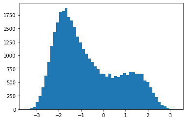

```python
import numpy as np
import matplotlib.pyplot as plt
np.random.seed(42)

# baca file
data = np.genfromtxt("https://raw.githubusercontent.com/APS-ITERA/Modul_Statistik/main/Modul_MonteCarlo/data_pop.txt")

print("N:", len(data))

mean_pop = data.mean()
sigma_pop = data.std()

print("Mean population: ", mean_pop, "\nStd Dev Population: ", sigma_pop)

count, bins, ignored = plt.hist(data, bins=51);
```

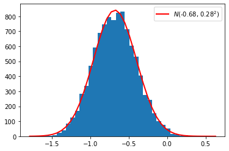

```python
Nsample = 25
Nsampling = 10000

meansamples = []
for i in range(Nsampling):
    sample = np.random.choice(data, Nsample)
    meansamples.append(np.mean(sample))


count, bins, ignored = plt.hist(meansamples, bins=41);
width = bins[1] - bins[0]

sample_sigma = sigma_pop/np.sqrt(Nsample)
sample_mean = mean_pop

plt.plot(bins, Nsampling*width * 1/(sample_sigma * np.sqrt(2 * np.pi)) * np.exp( - (bins - sample_mean)**2 / (2 * sample_sigma**2) ),
         linewidth = 2,
         color = 'r',
         label = f"$N$({round(sample_mean, 2)}, {round(sample_sigma, 2)}$^2$)")

plt.legend()
```

### Standard score / $z$-score

- Normal distribution very often used in measurement, to define how far a particular data/measurement from the collection of normally distributed data, we used $z$-score (normal score, $z$-value, standard score): $$z = \frac{x - \mu}{\sigma}$$ where: $\mu$ is the mean of the population & $\sigma$ is the standard deviation of the population
  - The absolute value of $z$ represents the distance between that raw score $x$ and the population mean in units of the standard deviation. $z$ is negative when the raw score is below the mean, positive when above.
  - Calculating $z$ using this formula requires the population mean and the population standard deviation, not the sample mean or sample deviation. But knowing the true mean and standard deviation of a population is often unrealistic except in cases such as standardized testing, where the entire population is measured.
  - When the population mean and the population standard deviation are unknown, the standard score may be calculated using the sample mean and sample standard deviation as estimates of the population values.

[figure not shown]

**Example**

- Nilai fluks bintang X ketika dilakukan pengamatan terus menerus mengikuti distribusi normal dengan rerata 30000 dan standar deviasi 500. Berapa peluang bintang ini suatu hari menghasilkan fluks < 29175?

**Menggunakan tabel $z$-score**

Contoh salah satu varian tabel $z$-score:

[figure not shown]

- Pertama kita hitung nilai z terlebih dahulu (kita "petakan" ke Gaussian standar dengan $\mu = 0$ dan $\sigma=1$). $$z = \frac{29175 - 30000}{500} = -1.65$$
- Dari tabel tersebut kita peroleh bahwa luas area di bawah kurva antara mean (0) dengan $z=-1.65$, yaitu $$\text{Pr}(0<z<1.65) = \text{Pr}(-1.65<z<0) = 0.4505$$,
- artinya untuk nilai $\text{Pr}(z<-1.65) = \text{Pr}(x<29175) = 1 - (0.5 + 0.4505) = 0.0495$ atau $0.5 - 0.4505 = 0.0495$

**Menggunakan `scipy.stats`**

```python
from scipy.stats import norm

peluang_kurang_dari_x = norm.cdf(x=29175, loc=30000, scale=500)

print(peluang_kurang_dari_x)
```

```
0.0494714680336481
```

**Example**

- Distribusi nilai Fisika Dasar 3000 mahasiswa ITERA mengikuti profil distribusi normal dengan rata-rata 50 dan standar deviasi 10. Saitama adalah mahasiswa elit, masuk dalam 1% kelompok mahasiswa dengan nilai tertinggi. Perkirakan nilai minimal Saitama sehingga ia bisa masuk mahasiswa elit?

**Menggunakan tabel $z$-score**

- Mencari batas nilai untuk elit 1% teratas artinya sama dengan kita mencari batas ($x$) sehingga, $$\text{P}(\text{nilai} > x) = 0.01$$ atau $$\text{P}(\text{nilai} < x) = 0.99$$
- Nilai batas $x$ tersebut akan bersesuaian dengan nilai $z$ tertentu pada tabel di atas, karena tabelnya memberi nilai integral 0 hingga $z$ nilai yang sesuai adalah $P(0 \rightarrow z) = 0.49$
- Nilai $z$ pada tabel yang memiliki nilai terdekat dengan $P(0 \rightarrow z) = 0.49$ adalah $z = 2.33$ yang bersesuaian dengan $x = 50 + 2.33 \cdot 10 = 73.3$
- Dapat disimpulkan, untuk masuk dalam kelompok mahasiswa elit (1% teratas), nilai Fisika Dasarnya minimal: 73.3

**Menggunakan `scipy.stats`**

```python
from scipy.stats import norm
nilai = norm.ppf(q=0.99, loc=50, scale=10)

print("Untuk masuk dalam kelompok mahasiswa elit (1% teratas), nilai fisika dasarnya minimal: ", nilai)
```

```
Untuk masuk dalam kelompok mahasiswa elit (1% teratas), nilai fisika dasarnya minimal:  73.2634787404084
```

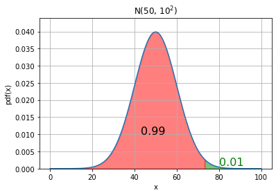

```python
## Coba kita plot
mu = 50
sig = 10

xlow = 0 # untuk plot nilai (0 hingga 100) dengan binsize 0.01 -> generate x
xhigh = 100
dx = 0.01

tidak_elit = norm.cdf(x=nilai, loc=mu, scale=sig) # CDF dr -infty hingga x -> 0.99
elit = 1 - tidak_elit # -> 0.01

fig, ax = plt.subplots()
x = np.arange(xlow, xhigh, dx) # generate
ax.plot(x, norm.pdf(x, loc=mu, scale=sig)) # plot kurva pdf
ax.set_title(f"N({mu}, ${sig}^2$)")
ax.set_xlabel('x')
ax.set_ylabel('pdf(x)')
ax.grid(True)

px = np.arange(nilai, xhigh, dx) # plot sisi kanan (elit)
ax.set_ylim(0, 1.1*norm.pdf(mu, loc=mu, scale=sig))
ax.fill_between(px, norm.pdf(px, loc=mu, scale=sig), alpha=0.5, color='g')

px1 = np.arange(xlow, nilai, dx) # plot arsir sisi kiri (tidak elit)
ax.fill_between(px1, norm.pdf(px1,loc=mu,scale=sig), alpha=0.5, color='r')
ax.text(43, 0.01, round(tidak_elit, 2), fontsize=16) # tulis teks "0.99"
ax.text(80, 0.001, round(elit, 2), fontsize=16, color='g') # tulis teks "0.01"
plt.show()
```

## Other important distribution in sciences

Learn by yourself / when you need it... ;)

Source: https://vitalflux.com/types-probability-distributions-defined-examples/

- **Exponential distribution** is a continuous probability distribution that describes the waiting time until the next event (success, failure, arrival, etc) in a Poisson process.
  - How much time will go before a customer call happens?
  - How much time will go before the next customer arrive in the shop?
  - How much time will pass by before the next robbery happens in any part of the city?
  - How much time will pass by before the next childbirth in the city?
  - How much time will go until the customer finishes browsing and actually purchases something in your store (success)?
  - How much time will go until the hardware on AWS EC2 fails (failure)?
  - How much time will go until the bus arrives (arrival)?
- **Beta distribution** is defined on the interval [0, 1] parameterized by two positive shape parameters α and β, that appear as exponents of the random variable and control the shape of the distribution. Simply speaking, Beta distribution is used to represent percentages, proportion or probability outcomes. It can also be said as the distribution of probabilities. Here are some examples which could be modeled using beta distribution:
  - How likely it is that the preferred candidate for mayor will receive 70% of the vote. 70% of the vote (0.7) here is the proportion or probability that falls in the limit [0,1].
  - How likely is that President Trump will win 2020 presidential elections? Note the value will fall within the limit [0, 1]
- **Gamma distribution** is a continuous probability distribution that is used to model the continuous variables that are always positive and have skewed distributions. It is a two-parameter family of continuous probability distributions. The exponential distribution, Erlang distribution, and chi-squared distribution are special cases of the gamma distribution. It is a distribution that arises naturally in processes for which the waiting times between events are relevant. It can be thought of as a waiting time between Poisson distributed events. Here are some of the examples of a gamma distribution:
  - In life testing, the waiting time until death is a random variable that is frequently modeled with a gamma distribution
  - The size of loan defaults or aggregate insurance claims
  - The flow of items through manufacturing and distribution processes
  - The load on web servers
  - The many and varied forms of telecom exchange
- **Chi distribution** and **Chi-squared distribution** Chi-squared distribution with k degrees of freedom is the distribution of a sum of the squares of k independent standard normal random variables. It is a special case of the gamma distribution and is one of the most widely used probability distributions in inferential statistics, notably in hypothesis testing and in construction of confidence intervals. It is used in the common chi-square tests for some of the following reasons:
  - The goodness of fit of an observed distribution to a theoretical one
  - The independence of two criteria of classification of qualitative data
  - In confidence interval estimation for a population standard deviation of a normal distribution from a sample standard deviation.

    Example of chi distribution:
  - Rayleigh distribution (chi distribution with two degrees of freedom)
  - Maxwell–Boltzmann distribution of the molecular speeds in an ideal gas (chi distribution with three degrees of freedom)
- **Student's t distribution (t-distribution)** is any member of a family of continuous probability distributions that arise *when estimating the mean of a normally-distributed population in situations where the sample size is small and the population's standard deviation is unknown*. It was developed by English statistician William Sealy Gosset under the pseudonym "Student".
- **F-distribution** a continuous probability distribution that arises frequently as the null distribution of a test statistic, most notably in the analysis of variance (ANOVA) and other F-tests.

https://en.wikipedia.org/wiki/List_of_probability_distributions